# **An Analysis of Socioeconomical Factors and Rates of Happiness**

# Fall 2024 Data Science Project

Nelithra Jayalatharachchi, Diya Rahi and Purva Chimurkar

**Contributions**

Nelithra Jayalatharachchi: Worked on Data Curation, Insights and Conclusions, and helped with Visualizations.

Diya Rahi: Introduction, Worked on Data Curation, Visualization, and helped with Insights and Conclusions.

Purva Chimurkar: Worked on Data Curation, Exploratory Data Analysis and conducted the Primary Analysis.

# **1. Introduction**

Life satisfaction is a critical measure of well-being that reflects an individual’s overall happiness and fulfillment. In our project, we aim to analyze how various demographic factors, such as age, gender, education level, and ethnicity influence life satisfaction. Using data from Statistics Canada, we will explore trends and correlations in happiness ratings reported on a scale of 1 to 10 by individuals from a variety of socieconomic backgrounds.This dataset was chosen for its comprehensive nature, reputable source, and relevance to our shared interest in understanding societal happiness. It offers a unique opportunity to explore whether certain demographic groups consistently report higher levels of satisfaction and to investigate claims about whether specific generations “had it better.” The insights derived from this analysis could inform policies aimed at improving societal well-being and addressing inequalities. The main questions we hope to answer is how different factors influence an indiviudal's happiness rating, and if differing combinations of these factors in an individual affect this rating. Answering these questions will help us determine which demographic groups have lower happiness ratings, which will then be used in next steps to determine why there is this dispartiy in happiness ratings, and what can be done to address these causes for low happiness.

# **2. Data Curation**

Our data, "Life satisfaction by gender and other selected sociodemographic characteristics" is from Statistics Canada, the official national statistics agency of the Government of Canada. We will be using the Age, Location, and Education subsections from this data for our analysis. Since this dataset contains a extra information that is not applicable, we will be cleaning this data by examining if there are any missing values (and resolving them if there are any present), and splitting the data into three separate, examinable DataFrames for each factor.

# 2.1 Data Cleaning

The first step is to load and display the initial dataset:

```python
# Import statements.
import pandas as pd
import requests
from datetime import datetime
from scipy import stats
import matplotlib.pyplot as plt
import seaborn as sns
import numpy as np

# Loading csv file.
life_df = pd.read_csv('life-satisfaction.csv')

life_df
```

|  | Unnamed: 0 | Life satisfaction rating between 0 and 5 - Total | Life satisfaction rating of 6 or 7 - Total | Life satisfaction rating of 8, 9 or 10 - Total | Life satisfaction rating between 0 and 5 - Men | Life satisfaction rating of 6 or 7 - Men | Life satisfaction rating of 8, 9 or 10 - Men | Life satisfaction rating between 0 and 5 - Women | Life satisfaction rating of 6 or 7 - Women | Life satisfaction rating of 8, 9 or 10 - Women |
| --- | --- | --- | --- | --- | --- | --- | --- | --- | --- | --- |
| 0 | Total, 15 years and over | 28.3 | 31.3 | 40.4 | 28.4 | 31.7 | 40.0 | 28.2 | 31.0 | 40.8 |
| 1 | 15 to 24 years | 26.8 | 30.7 | 42.5 | 24.6 | 30.2 | 45.1 | 29.2 | 31.2 | 39.6 |
| 2 | 25 to 54 years | 32.7 | 35.3 | 32.0 | 33.5 | 34.8 | 31.7 | 31.8 | 36.0 | 32.3 |
| 3 | 55 to 64 years | 25.8 | 30.0 | 44.2 | 24.4 | 33.3 | 42.4 | 27.2 | 26.8 | 46.1 |
| 4 | 65 years and over | 21.6 | 24.1 | 54.3 | 22.1 | 24.4 | 53.5 | 21.2 | 23.9 | 54.9 |
| 5 | Total, by immigrant status | 28.3 | 31.3 | 40.4 | 28.4 | 31.7 | 40.0 | 28.2 | 31.0 | 40.8 |
| 6 | Non-immigrants 9 | 26.3 | 30.4 | 43.3 | 25.9 | 31.2 | 42.9 | 26.7 | 29.6 | 43.7 |
| 7 | Immigrants 10 | 33.2 | 33.0 | 33.9 | 34.4 | 32.2 | 33.4 | 31.9 | 33.7 | 34.3 |
| 8 | Total, by visible minority group 11 | 28.3 | 31.3 | 40.4 | 28.4 | 31.7 | 40.0 | 28.2 | 31.0 | 40.8 |
| 9 | Visible minority population | 32.9 | 35.6 | 31.6 | 33.3 | 34.3 | 32.3 | 32.4 | 36.8 | 30.8 |
| 10 | Not a visible minority 12 | 26.5 | 29.7 | 43.7 | 26.5 | 30.7 | 42.8 | 26.6 | 28.8 | 44.6 |
| 11 | Total, by Indigenous identity 13 | 28.3 | 31.3 | 40.4 | 28.4 | 31.7 | 40.0 | 28.2 | 31.0 | 40.8 |
| 12 | Indigenous identity 13 | 40.5 | 28.2 | 31.3 | 41.9 | 22.7 | 35.4 | 38.9 | 33.9 | 27.1 |
| 13 | Non-Indigenous identity | 27.9 | 31.4 | 40.7 | 27.9 | 32.0 | 40.1 | 27.9 | 30.9 | 41.2 |
| 14 | Total, persons with and without a disability, ... | 28.3 | 31.3 | 40.4 | 28.4 | 31.7 | 40.0 | 28.2 | 31.0 | 40.8 |
| 15 | Persons with a disability, difficulty or long-... | 35.9 | 32.6 | 31.5 | 36.6 | 33.3 | 30.1 | 35.3 | 32.0 | 32.7 |
| 16 | Persons without a disability, difficulty or lo... | 21.8 | 30.3 | 48.0 | 22.1 | 30.4 | 47.6 | 21.4 | 30.1 | 48.5 |
| 17 | Total, LGBTQ2+ and non-LGBTQ2+ people | 28.3 | 31.3 | 40.4 | 28.4 | 31.7 | 40.0 | 28.2 | 31.0 | 40.8 |
| 18 | LGBTQ2+ people 17 | 42.5 | 29.6 | 27.9 | 37.9 | 36.9 | 25.2 | 45.7 | 24.7 | 29.7 |
| 19 | Non-LGBTQ2+ people 18 | 27.3 | 31.5 | 41.3 | 27.8 | 31.4 | 40.8 | 26.7 | 31.6 | 41.7 |
| 20 | Total, highest certificate, diploma or degree | 28.3 | 31.3 | 40.4 | 28.4 | 31.7 | 40.0 | 28.2 | 31.0 | 40.8 |
| 21 | No certificate, diploma or degree | 28.4 | 26.0 | 45.5 | 30.1 | 25.3 | 44.6 | 26.5 | 26.9 | 46.6 |
| 22 | Secondary (high) school diploma or equivalency... | 29.9 | 31.4 | 38.7 | 27.6 | 34.1 | 38.3 | 32.2 | 28.7 | 39.1 |
| 23 | Postsecondary certificate, diploma or degree | 27.6 | 32.6 | 39.8 | 28.2 | 32.4 | 39.4 | 27.0 | 32.8 | 40.1 |
| 24 | Total, by main activity | 28.3 | 31.3 | 40.4 | 28.4 | 31.7 | 40.0 | 28.2 | 31.0 | 40.8 |
| 25 | Working at a paid job or business | 27.6 | 35.7 | 36.7 | 27.8 | 35.7 | 36.5 | 27.2 | 35.7 | 37.0 |
| 26 | Retired | 20.0 | 24.3 | 55.7 | 20.7 | 25.8 | 53.5 | 19.3 | 23.0 | 57.7 |
| 27 | Other activity 19 | 35.4 | 28.6 | 35.9 | 35.7 | 27.1 | 37.2 | 35.3 | 29.7 | 35.0 |
| 28 | Total, urban and rural areas 20 | 28.3 | 31.3 | 40.4 | 28.4 | 31.7 | 40.0 | 28.2 | 31.0 | 40.8 |
| 29 | Urban areas 20 | 29.4 | 31.4 | 39.2 | 29.6 | 31.6 | 38.8 | 29.1 | 31.3 | 39.6 |
| 30 | Rural areas 20 | 21.2 | 30.8 | 48.0 | 20.9 | 32.2 | 46.9 | 21.7 | 29.1 | 49.2 |

Now we will clean the dataset. We will check to see how much of the data is missing, and if it this values need to be dropped/replaced.

```python
# Checking how much data is missing:
nan_percentage = life_df.isna().mean()

nan_percentage # As you can see there are no Nan values for us to replace/drop.
```

|  | 0 |
| --- | --- |
| Unnamed: 0 | 0.0 |
| Life satisfaction rating between 0 and 5 - Total | 0.0 |
| Life satisfaction rating of 6 or 7 - Total | 0.0 |
| Life satisfaction rating of 8, 9 or 10 - Total | 0.0 |
| Life satisfaction rating between 0 and 5 - Men | 0.0 |
| Life satisfaction rating of 6 or 7 - Men | 0.0 |
| Life satisfaction rating of 8, 9 or 10 - Men | 0.0 |
| Life satisfaction rating between 0 and 5 - Women | 0.0 |
| Life satisfaction rating of 6 or 7 - Women | 0.0 |
| Life satisfaction rating of 8, 9 or 10 - Women | 0.0 |

**dtype:** float64

By finding that percentage of data that is missing or NaN to be 0% in all categories, we determined that there are no missing values to replace/"clean."

Now, we will split our data into our three categories of interest: Age, Location, and Education

```python
# Age
columns_of_interest_age = [
    'Unnamed: 0',
    'Life satisfaction rating between 0 and 5 - Total',
    'Life satisfaction rating of 6 or 7 - Total',
    'Life satisfaction rating of 8, 9 or 10 - Total'
]

# Location
columns_of_interest_location = [
    'Unnamed: 0',
    'Life satisfaction rating between 0 and 5 - Total',
    'Life satisfaction rating of 6 or 7 - Total',
    'Life satisfaction rating of 8, 9 or 10 - Total'
]

# Education
columns_of_interest_education = ['No certificate, diploma or degree',
                   'Secondary (high) school diploma or equivalency certificate',
                   'Postsecondary certificate, diploma or degree']
```

Our data is now fully curated and ready to explore.

# **4. Exploratory Data Analysis**

This section dives into exploring the data for each of the cateogries we focus on -- age, location and education. THe data was cleaned and graphed or tested to draw conclusions on the happiness levels of people based on the factors previously mentioned.

# **Summary Statistics and Plots:**

```python
# Basic size information:
life_df.shape
```

```
(31, 10)
```

```python
# Basic summary:
life_df.describe()
```

|  | Life satisfaction rating between 0 and 5 - Total | Life satisfaction rating of 6 or 7 - Total | Life satisfaction rating of 8, 9 or 10 - Total | Life satisfaction rating between 0 and 5 - Men | Life satisfaction rating of 6 or 7 - Men | Life satisfaction rating of 8, 9 or 10 - Men | Life satisfaction rating between 0 and 5 - Women | Life satisfaction rating of 6 or 7 - Women | Life satisfaction rating of 8, 9 or 10 - Women |
| --- | --- | --- | --- | --- | --- | --- | --- | --- | --- |
| count | 31.000000 | 31.000000 | 31.000000 | 31.000000 | 31.000000 | 31.000000 | 31.000000 | 31.000000 | 31.000000 |
| mean | 28.900000 | 30.803226 | 40.300000 | 28.874194 | 31.203226 | 39.951613 | 28.870968 | 30.522581 | 40.603226 |
| std | 4.966957 | 2.632677 | 6.204085 | 4.876062 | 3.163488 | 5.984306 | 5.163603 | 3.166776 | 6.693205 |
| min | 20.000000 | 24.100000 | 27.900000 | 20.700000 | 22.700000 | 25.200000 | 19.300000 | 23.000000 | 27.100000 |
| 25% | 27.050000 | 30.150000 | 37.700000 | 27.050000 | 30.950000 | 37.750000 | 26.850000 | 29.350000 | 38.050000 |
| 50% | 28.300000 | 31.300000 | 40.400000 | 28.400000 | 31.700000 | 40.000000 | 28.200000 | 31.000000 | 40.800000 |
| 75% | 29.650000 | 31.400000 | 42.900000 | 29.850000 | 32.300000 | 42.600000 | 30.500000 | 31.450000 | 42.700000 |
| max | 42.500000 | 35.700000 | 55.700000 | 41.900000 | 36.900000 | 53.500000 | 45.700000 | 36.800000 | 57.700000 |

# **Age**

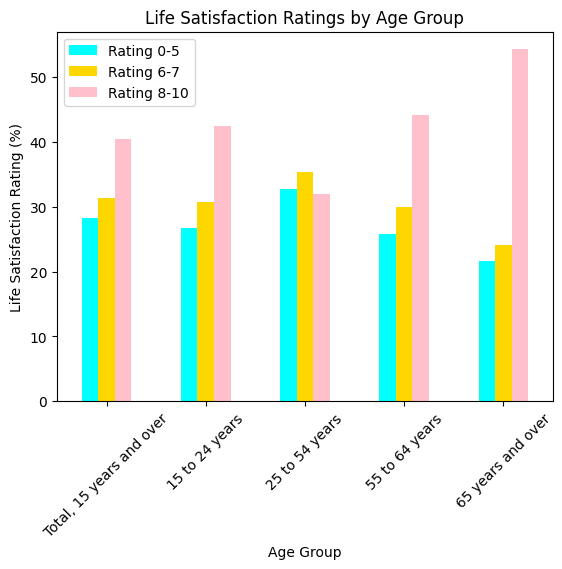

|  | Rating 0-5 | Rating 6-7 | Rating 8-10 |
| --- | --- | --- | --- |
| count | 5.000000 | 5.000000 | 5.000000 |
| mean | 27.040000 | 30.280000 | 42.680000 |
| std | 4.025295 | 4.021443 | 8.009806 |
| min | 21.600000 | 24.100000 | 32.000000 |
| 25% | 25.800000 | 30.000000 | 40.400000 |
| 50% | 26.800000 | 30.700000 | 42.500000 |
| 75% | 28.300000 | 31.300000 | 44.200000 |
| max | 32.700000 | 35.300000 | 54.300000 |

```python
# Age

# Filtering the dataframe for age groups and satisfaction ratings
life_df_age_groups = life_df[columns_of_interest_age]
life_df_age_groups.columns = ['Age Group', 'Rating 0-5', 'Rating 6-7', 'Rating 8-10']

# Dropping rows that are not related to age groups
age_related_rows = ['Total, 15 years and over', '15 to 24 years', '25 to 54 years', '55 to 64 years', '65 years and over']
life_df_age_groups = life_df_age_groups[life_df_age_groups['Age Group'].isin(age_related_rows)]
life_df_age_groups.set_index('Age Group', inplace=True)

# Creating bar chart
life_df_age_groups.plot(kind='bar', title="Life Satisfaction Ratings by Age Group", color=['cyan', 'gold', 'pink'])
plt.ylabel("Life Satisfaction Rating (%)")
plt.xticks(rotation=45)
plt.show()
life_df_age_groups.describe()
```

```python
total_group = life_df_age_groups.loc["Total, 15 years and over"]

# Sample size for groups
n_total = n_age_group = 1

# Function to perform two-tailed Z-test on each category
def perform_z_test(group1, group2, n1, n2):
    z_scores = {}
    p_values = {}
    for rating in group1.index:
        mean_diff = group1[rating] - group2[rating]
        std_diff = np.sqrt((group1[rating]**2 / n1) + (group2[rating]**2 / n2))
        z_score = mean_diff / std_diff
        p_value = stats.norm.sf(abs(z_score)) * 2
        z_scores[rating] = z_score
        p_values[rating] = p_value
    return z_scores, p_values

# Loop through each age group and perform Z-test for each age group to the total average
results = []
for age_group in life_df_age_groups.index:
    if age_group != 'Total, 15 years and over':
        age_group_values = life_df_age_groups.loc[age_group]
        z_scores, p_values = perform_z_test(age_group_values, total_group, n_age_group, n_total)
        results.append((age_group, z_scores, p_values))

for result in results:
    age_group, z_scores, p_values = result
    print(f"\n{age_group}:")
    for rating in z_scores:
        print(f"{rating}: Z-score = {z_scores[rating]:.5f}, p-value = {p_values[rating]:.5f}")
```

```
15 to 24 years:
Rating 0-5: Z-score = -0.03849, p-value = 0.96930
Rating 6-7: Z-score = -0.01369, p-value = 0.98908
Rating 8-10: Z-score = 0.03581, p-value = 0.97143

25 to 54 years:
Rating 0-5: Z-score = 0.10174, p-value = 0.91896
Rating 6-7: Z-score = 0.08478, p-value = 0.93243
Rating 8-10: Z-score = -0.16299, p-value = 0.87053

55 to 64 years:
Rating 0-5: Z-score = -0.06528, p-value = 0.94795
Rating 6-7: Z-score = -0.02998, p-value = 0.97608
Rating 8-10: Z-score = 0.06346, p-value = 0.94940

65 years and over:
Rating 0-5: Z-score = -0.18820, p-value = 0.85072
Rating 6-7: Z-score = -0.18226, p-value = 0.85538
Rating 8-10: Z-score = 0.20538, p-value = 0.83728
```

**Conclusion**

H0: There is no signifcant difference between the ratings of the age group "15 to 24 years" (and every other age group range from the data) to the total age group, "Total, 15 years and over"

HA: There is a signifcant difference between the ratings of the age group "15 to 24 years" (and every other age group range from the data) to the total age group, "Total, 15 years and over"

# **Location**

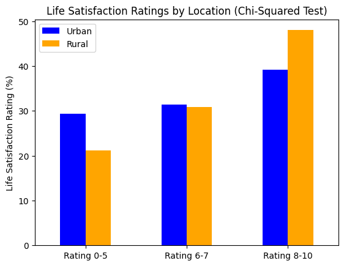

```
Chi-Squared Statistic: 2.222714930786606, p-value: 0.32911189969430366
```

```python
# Location

from scipy.stats import chi2_contingency

# Filter columns for rural vs urban areas and satisfaction ratings
life_df_location = life_df[columns_of_interest_location]
life_df_location.columns = ['Location', 'Rating 0-5', 'Rating 6-7', 'Rating 8-10']

# Filter rows for just urban and rural
filtered_df = life_df_location[life_df_location['Location'].isin(['Urban areas 20', 'Rural areas 20'])]

contingency_table = pd.DataFrame({
    'Urban': filtered_df[filtered_df['Location'] == 'Urban areas 20'].iloc[0, 1:],
    'Rural': filtered_df[filtered_df['Location'] == 'Rural areas 20'].iloc[0, 1:]
})

# Perform the Chi-Squared test
chi2, p, dof, expected = chi2_contingency(contingency_table.T)

# bar chart for data visualization
contingency_table.plot(kind='bar', title="Life Satisfaction Ratings by Location (Chi-Squared Test)", color=['blue', 'orange'])
plt.ylabel("Life Satisfaction Rating (%)")
plt.xticks(rotation=0)
plt.show()

# Output the Chi-Squared statistic and p-value
print(f"Chi-Squared Statistic: {chi2}, p-value: {p}")
```

**Conclusion**

Null Hypothesis (H0): There is no significant difference in the distribution of life satisfaction ratings between urban and rural areas.

Alternative Hypothesis (HA): There is a significant difference in the distribution of life satisfaction ratings between urban and rural areas.

Based on the Chi-Squared test results, with a Chi-Squared statistic of 2.22 and a p-value of 0.329, we can conclude that there is no statistically significant difference in life satisfaction ratings between urban and rural areas. The p-value, being higher than the common threshold of 0.05, indicates that we fail to reject the null hypothesis, meaning that the distribution of life satisfaction ratings across the categories (0-5, 6-7, 8-10) is similar for both urban and rural locations. Any differences observed in the data are likely due to random variation rather than a true underlying difference. Therefore, life satisfaction appears to be consistent across these environments, with no strong evidence to suggest that location significantly impacts overall satisfaction levels.

# **Education**

The following section is on hypothesis testing regarding education level and life satisfaction. The first bar graph simply displays life satisfaction ratings based on the three education levels: No certificate, diploma or degree, Secondary (high) school diploma or equivalency certificate, and Postsecondary certificate, diploma or degree. This graph is just for visualizing the data. The next segment shows an ANOVA test hypothesis analysis on the data in search of correlations between education level and life satisfaction.

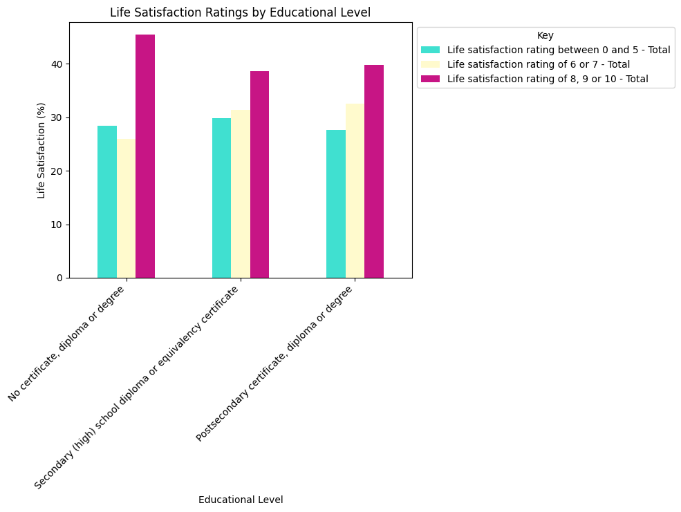

```python
# Education

# Extracting the relevant columns for analysing the relationship between education
# level and life satisfaction.
satisfaction_ratings = ['Life satisfaction rating between 0 and 5 - Total',
                       'Life satisfaction rating of 6 or 7 - Total',
                       'Life satisfaction rating of 8, 9 or 10 - Total']

# Filter life_df for the selected education levels.
filtered_df = life_df[life_df['Unnamed: 0'].isin(columns_of_interest_education)]

# Colors for the graph.
colors = ['turquoise', 'lemonchiffon', 'mediumvioletred']

# Create a bar plot for basic visualization of the data:
filtered_df.set_index('Unnamed: 0')[satisfaction_ratings].plot(kind='bar', color=colors)
plt.title('Life Satisfaction Ratings by Educational Level')
plt.xlabel('Educational Level')
plt.ylabel('Life Satisfaction (%)')
plt.xticks(rotation=45, ha='right')
plt.legend(title='Key', bbox_to_anchor=(1, 1))
plt.show()
```

```
p-value: 0.9999807153325967
```

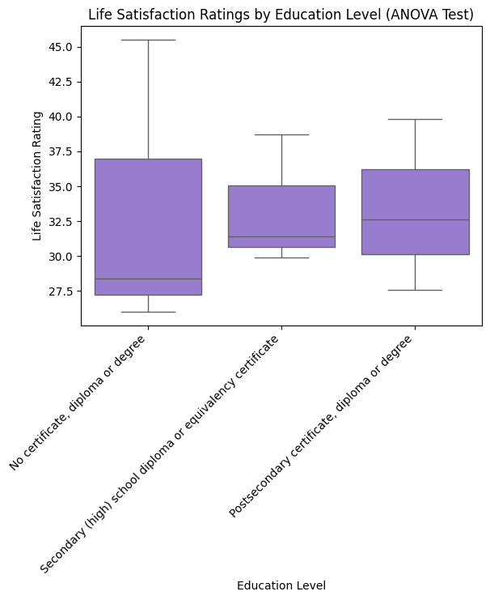

```python
# The oneway function requires an array of input.
# The following for loop creates an array for each category's data.
data_for_anova = [filtered_df[filtered_df['Unnamed: 0'] == level][satisfaction_ratings].values.flatten()
                  for level in columns_of_interest_education]

# ANOVA testing:
_, pvalue = stats.f_oneway(*data_for_anova)

print(f"p-value: {pvalue}")

# Creating a box and whisker plot to display the means of each group.
plt.xticks(rotation=45, ha='right')
sns.boxplot(x='Unnamed: 0', y='value', data=pd.melt(filtered_df[satisfaction_ratings + ['Unnamed: 0']], id_vars=['Unnamed: 0']), order=columns_of_interest_education, color='mediumpurple')
plt.xlabel('Education Level')
plt.ylabel('Life Satisfaction Rating')
plt.title('Life Satisfaction Ratings by Education Level (ANOVA Test)')
plt.show()
```

**Conclusion**

Originally, we hypothesized that there would be a positive correlation between higher education levels and increased life satisfaction. However, after running the ANOVA test on the data, we got a p value of 0.999. This is significantly greater than our alpha value/significance level of 0.05, meaning there is no significant difference between the mean life satisfaction ratings of the 3 eduction levels: No certificate, diploma or degree, Secondary (high) school diploma or equivalency certificate, and Postsecondary certificate, diploma or degree. Although this is a preliminary test, it indicates that education level may not have as significant of an impact on life satisfaction as we originally thought, disproving our hypothesis.

# **5. Primary Analysis**

In this section we will analyze the ideal combination of factors for happiness, focusing specifically on three factors-- age, location and education. The goal of our analysis is to use a regression model to predict high satisfaction levels (Rating 8–10) for different age groups based on the targetted features (age, education, and location data).

First, we create three separate DataFrames for age, location, and education-level life satisfaction ratings, then merges them into one unified dataset.

```python
from sklearn.preprocessing import OneHotEncoder
from sklearn.model_selection import cross_val_score
from sklearn.linear_model import Ridge
from sklearn.compose import ColumnTransformer
from sklearn.pipeline import Pipeline
from sklearn.metrics import mean_squared_error, r2_score

# Restructure the data to have one row per demographic combination
restructured_data = {
    'Age': ['15 to 24 years', '25 to 54 years', '55 to 64 years', '65 years and over', None, None, None, None, None],
    'Location': [None, None, None, None, 'Urban areas 20', 'Rural areas 20', None, None, None],
    'Education': [None, None, None, None, None, None,
                 'No certificate, diploma or degree',
                 'Secondary (high) school diploma or equivalency certificate',
                 'Postsecondary certificate, diploma or degree'],
    'Rating_0_5': [26.8, 32.7, 25.8, 21.6, 29.4, 21.2, 28.4, 29.9, 27.6],
    'Rating_6_7': [30.7, 35.3, 30.0, 24.1, 31.4, 30.8, 26.0, 31.4, 32.6],
    'Rating_8_10': [42.5, 32.0, 44.2, 54.3, 39.2, 48.0, 45.5, 38.7, 39.8]
}

df = pd.DataFrame(restructured_data)
```

Next we will train a linear regression model to predict high life satisfaction ratings (8–10) based on age, location, and education. After training the model, we evaluate the model's performance using Mean Squared Error (MSE) and R² Score.

```python
preprocessor = ColumnTransformer(
    transformers=[
        ('cat', OneHotEncoder(drop='first', sparse_output=False), ['Age', 'Location', 'Education'])
    ],
    remainder='passthrough'
)

X = df[['Age', 'Location', 'Education']]
y = df[['Rating_0_5', 'Rating_6_7', 'Rating_8_10']]

# Train separate models for each satisfaction level and calculate training scores
models = {}
training_scores = {}

for col in y.columns:
    # Build the pipeline
    models[col] = Pipeline([
        ('preprocessor', preprocessor),
        ('regressor', Ridge(alpha=1.0))
    ])
    # Fit the model
    models[col].fit(X, y[col])

    # Calculate predictions on training data
    y_train_pred = models[col].predict(X)

    # Calculate R² and MSE
    mse = mean_squared_error(y[col], y_train_pred)
    r2 = r2_score(y[col], y_train_pred)

    # Store scores
    training_scores[col] = {'MSE': mse, 'R²': r2}

# Display training scores
print("\nTraining Scores:")
for level, scores in training_scores.items():
    print(f"\nFor {level}:")
    print(f"Mean Squared Error (MSE): {scores['MSE']:.2f}")
    print(f"R² Score: {scores['R²']:.2f}")

# Function to predict individual happiness levels
def predict_individual_happiness(age=None, location=None, education=None):
    """
    Predict the most likely happiness level for an individual based on demographics.
    """
    # Create input DataFrame for prediction
    input_data = pd.DataFrame({
        'Age': [age],
        'Location': [location],
        'Education': [education]
    })

    # Predict probabilities for each satisfaction level
    probabilities = {}
    for level, model in models.items():
        probabilities[level] = model.predict(input_data)[0]

    # Normalize probabilities to sum to 100
    total = sum(probabilities.values())
    probabilities = {k: (v / total) * 100 for k, v in probabilities.items()}

    # Determine the most likely satisfaction level
    most_likely_level = max(probabilities, key=probabilities.get)

    return most_likely_level, probabilities
```

```
Training Scores:

For Rating_0_5:
Mean Squared Error (MSE): 4.01
R² Score: 0.68

For Rating_6_7:
Mean Squared Error (MSE): 3.46
R² Score: 0.65

For Rating_8_10:
Mean Squared Error (MSE): 10.71
R² Score: 0.70
```

**Training Scores Analysis**

Based on the outputted Training score values, the R² values across all satisfaction levels (0–5, 6–7, 8–10) are consistently above 0.65, indicating the model explains a significant portion of the variance in life satisfaction ratings. However, around 30–35% of the variability remains unexplained, suggesting that additional features or interactions between Age, Location, and Education may improve the model. Notably, the model performs best for high satisfaction ratings (`Rating_8_10`), as reflected by the highest R² score (0.70), despite the relatively high MSE for this level.

Below are some example cases where we demonstrate how the model will predict an individual's most likely happiness level when provided their age, location, and education level information.

```python
# Example predictions
example_cases = [
    {'age': '25 to 54 years', 'location': 'Urban areas 20', 'education': 'Postsecondary certificate, diploma or degree'},
    {'age': '65 years and over', 'location': 'Rural areas 20', 'education': 'No certificate, diploma or degree'}
]

for case in example_cases:
    level, probs = predict_individual_happiness(
        age=case['age'], location=case['location'], education=case['education']
    )
    print(f"\nDemographics: Age={case['age']}, Location={case['location']}, Education={case['education']}")
    print(f"Predicted Happiness Level: {level}")
    print(f"Probabilities: {probs}")
```

```
Demographics: Age=25 to 54 years, Location=Urban areas 20, Education=Postsecondary certificate, diploma or degree
Predicted Happiness Level: Rating_6_7
Probabilities: {'Rating_0_5': 31.593615921737356, 'Rating_6_7': 34.63506676121, 'Rating_8_10': 33.77131731705265}

Demographics: Age=65 years and over, Location=Rural areas 20, Education=No certificate, diploma or degree
Predicted Happiness Level: Rating_8_10
Probabilities: {'Rating_0_5': 23.97413088426215, 'Rating_6_7': 27.017358272827813, 'Rating_8_10': 49.00851084291003}
```

**Happiness Level Prediction Analysis**

For the first case (25 to 54 years, urban area, postsecondary education), the most likely happiness level is Rating_6_7, with probabilities split roughly across all levels. For the second case (65 years and over, rural area, no certificate), the most likely happiness level is Rating_8_10, with a higher probability (49%) for high satisfaction compared to other levels. The predictions show how demographics influence happiness probabilities.

# **6. Visualization**

Below are visualizations that we use to draw conclusions on which demographic is most present in a given happiness rating level, which we can use to predict which types of people are more or less likely to appear in that happiness rating.

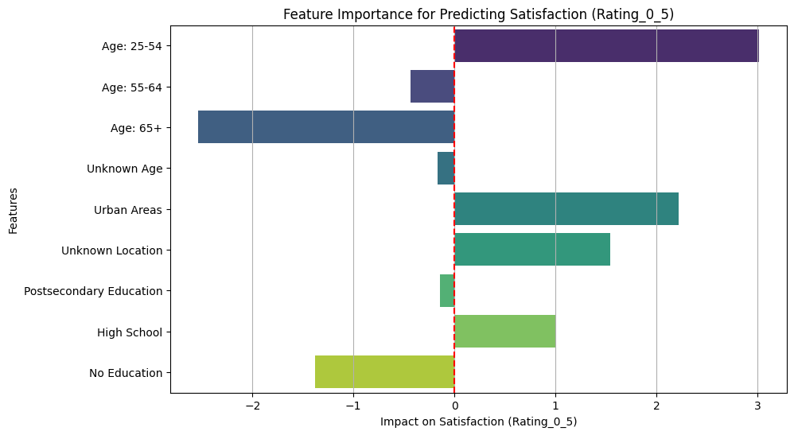

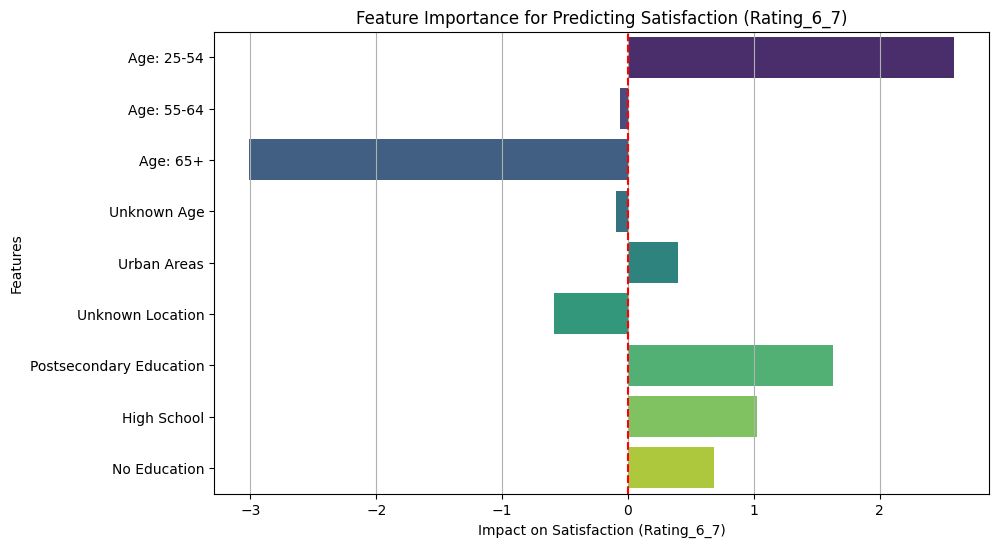

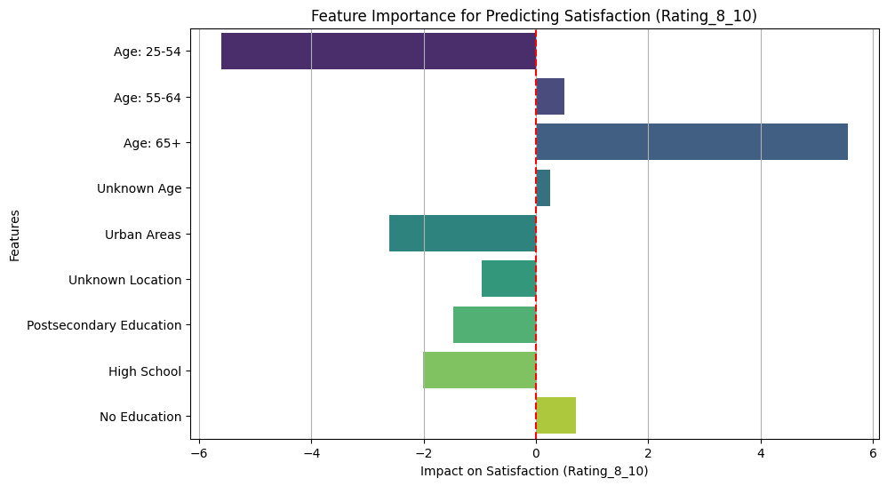

```python
better_labels = {
    'Age_None': 'Unknown Age',
    'Age_25 to 54 years': 'Age: 25-54',
    'Age_55 to 64 years': 'Age: 55-64',
    'Age_65 years and over': 'Age: 65+',
    'Location_None': 'Unknown Location',
    'Location_Urban areas 20': 'Urban Areas',
    'Education_None': 'No Education',
    'Education_Postsecondary certificate, diploma or degree': 'Postsecondary Education',
    'Education_Secondary (high) school diploma or equivalency certificate': 'High School'
}

for rating, pipeline in models.items():
    ridge_model = pipeline['regressor']

    coefficients = ridge_model.coef_
    feature_names = preprocessor.named_transformers_['cat'].get_feature_names_out(['Age', 'Location', 'Education'])
    better_feature_names = [better_labels.get(name, name) for name in feature_names]

    feature_importance = pd.DataFrame({
        'Feature': better_feature_names,
        'Coefficient': coefficients
    })

    plt.figure(figsize=(10, 6))
    sns.barplot(data=feature_importance, x='Coefficient', y='Feature', hue='Feature', palette="viridis", dodge=False, legend=False)
    plt.title(f"Feature Importance for Predicting Satisfaction ({rating})")
    plt.xlabel(f"Impact on Satisfaction ({rating})")
    plt.ylabel("Features")
    plt.axvline(0, color='red', linestyle='--')
    plt.grid(axis='x')
    plt.show()
```

Below is an alternate visual for the same data. The regression plots below go a step further than the bar plots above because they include a line representing the overall trend of the given feature on happiness. Additionally, the shaded blue region in the plots below show the variance of the data, which is another feature excluded in the previous bar plots. Using all six plots togther, we can draw better conclusions.

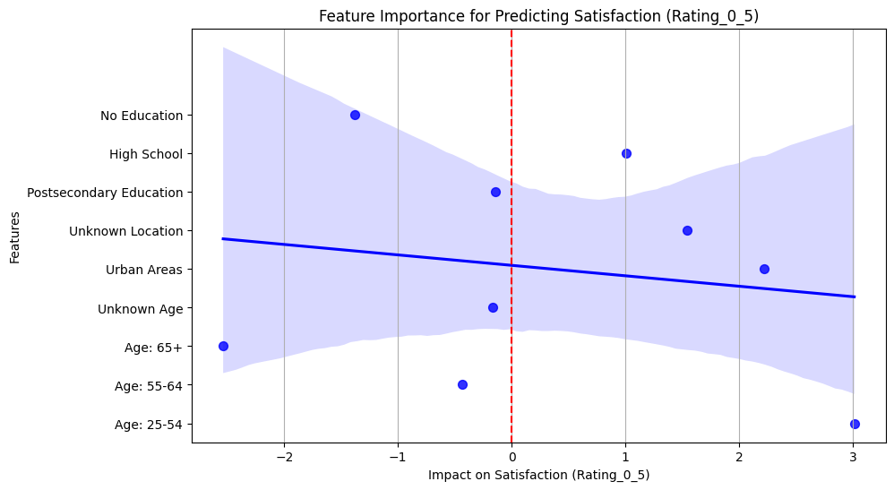

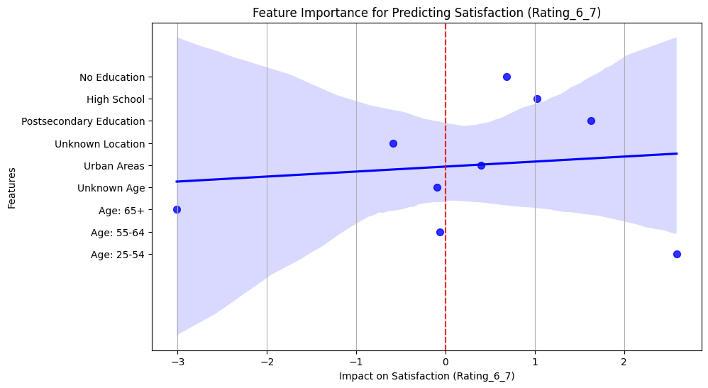

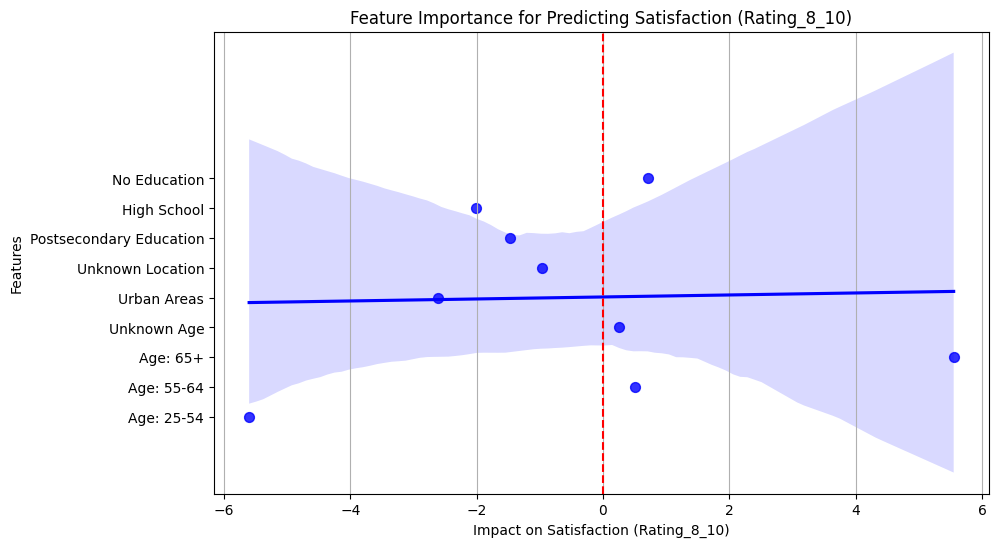

```python
better_labels = {
    'Age_None': 'Unknown Age',
    'Age_25 to 54 years': 'Age: 25-54',
    'Age_55 to 64 years': 'Age: 55-64',
    'Age_65 years and over': 'Age: 65+',
    'Location_None': 'Unknown Location',
    'Location_Urban areas 20': 'Urban Areas',
    'Education_None': 'No Education',
    'Education_Postsecondary certificate, diploma or degree': 'Postsecondary Education',
    'Education_Secondary (high) school diploma or equivalency certificate': 'High School'
}

for rating, pipeline in models.items():
    ridge_model = pipeline['regressor']

    coefficients = ridge_model.coef_
    feature_names = preprocessor.named_transformers_['cat'].get_feature_names_out(['Age', 'Location', 'Education'])
    better_feature_names = [better_labels.get(name, name) for name in feature_names]

    feature_importance = pd.DataFrame({
        'Feature': better_feature_names,
        'Coefficient': coefficients
    })

    feature_importance['Feature_Index'] = range(len(feature_importance))

    plt.figure(figsize=(10, 6))
    sns.regplot(data=feature_importance, x='Coefficient', y='Feature_Index', color='blue', scatter_kws={'s': 50})
    plt.yticks(feature_importance['Feature_Index'], feature_importance['Feature'])
    plt.title(f"Feature Importance for Predicting Satisfaction ({rating})")
    plt.xlabel(f"Impact on Satisfaction ({rating})")
    plt.ylabel("Features")
    plt.axvline(0, color='red', linestyle='--')
    plt.grid(axis='x')
    plt.show()
```

# **7. Insights and Conclusions**

The goal of our data analysis was to see whether an individual's age, education level, or geographic location impated their happiness level. As undergraduates, we are at a turning point in our lives while pursing higher educaion. Our specific scenario inspired us to explore relationship between aging and furthering your education on overall happiness. Additionally, the three of us come from different states, furthering our interest in the relationship between geographic location and happiness.

**Our findings**

The results of our linear regression model indicate that age, eduation level, and geogrpahic location do have an impact on an individual's overall happiness.

**Age**

Overall, the linear regression model predictions for the age feature suggest that happiness levels shift as you age, which was hinted by the varying happiness levels across different age groups. The general trendcseems to be that younger, working-age adults in urban areas with higher education tend towards moderate happiness, while older adults, even with less formal education and living in rural settings, are more likely to report high levels of happiness.

Our example cases support these findings. For example, in the first case, a younger adult in an urban area with higher education was predicted to have a moderate happiness level (Rating_6_7). While this group had the highest probability for a Rating_6_7 (34.64%), there was still a significant chance of falling into the lower (Rating_0_5, 31.59%) or higher (Rating_8_10, 33.77%) happiness categories. This could indicate a period of transition and uncertainty, where career and social factors play a major role in shaping overall satisfaction.

Our second example case, demonstrates a much different scenario for older adults. Even with less formal education and living in a rural setting, this group was strongly predicted to have a high happiness level (Rating_8_10), with a probability of 49.01%. The chances of falling into lower satisfaction categories were significantly lower (Rating_0_5, 23.97%, and Rating_6_7, 27.02%). Using contexual clues, we feel this may be a result of oldef individuals having more time to focus on personal relationships and fulfillment.

**Education Level**

While higher education was associated with the moderate happiness group, the lack of formal education in the older adult group did not hinder their high happiness prediction. This suggests that education may play a more significant role in shaping happiness for younger adults, potentially through career opportunities and social connections, but becomes a less influential factor on happiness level later in life.

Once again, our example cases support these findings. The first example shows that higher education was associated with the moderate happiness group for younger adults. While a postsecondary degree contributed to a higher probability of a Rating_6_7, it did not necessarily guarantee a high happiness level.

Contrastingly, the second example suggests that the lack of formal education in the older adult groups did not hinder their high happiness prediction. This could indicate that education may play a role in shaping happiness during younger years, but not later in life.

**Geographic Location**

For this example, our model indicated a slight difference between urban and rural locations in terms of happiness levels. Younger adults in urban areas with higher education were more likely to have a moderate happiness level, while older adults in rural settings with less education had a higher chance of having a high happiness level. However, the difference was not as prominent as the impact of age. It's possible that the specific characteristics of urban and rural areas in the dataset played a role, or that location is less directly related to happiness compared to age and education in this particular analysis.

**Next Steps**

Our findings indicate that individuals aged 25 to 54 generally experience the least happiness. Although this pattern changes and individuals become happier with age, this disparity is something we, as a society, should study. 25 to 54 year olds are the most burdened by financial strain, dependants, career struggles, and more. By investigating these areas, we can gain valuable insights into the challenges faced by this age group and develop interventions to promote happiness and well-being during this critical life stage.